# Solution

Simon Pierre KITEGI

2020-12-05

```r
library(haven);library(dplyr);library(purrr);library(tidyverse);library(factoextra);library(cluster)
```

## Assignment Context

One of our clients asked us to develop the best possible message for the product they offer. We developed a survey experiment that would display a random combination of phrases along with a price and the length of a subscription. Each respondent saw 12 random permutations of the message. For each permutation, the respondent was asked to rate `"How likely are you to download this mobile app?"`. The app we are referring to in this case was an app to help people sleep better.

Your goal now is to advice on the best combination of attributes displayed in the message. Each **attribute** (e.g. `price`) has multiple **levels** that, as explained, vary for each task.

Alongside the experiment, we conducted a regular survey with a set of questions related to sleep and socio-demographic behavior. Thanks to the survey we were able to describe a group of highly likely downloaders so that our client was able to understand the potential audience in the market.

### Your tasks

1. Find out how each attribute (and level) influences the overall likeliness to download (`experiment_data$answer`).
2. Describe the groups of respondents that we see in the data using the added demographic, psychological and behavioral data. Feel free to experiment with clustering techniques in addition to descriptives.

You are free to use any method that you think is reasonable for this challenge.

> Hint: The message testing experiment is a ratings-based conjoint on an ordinal scale.

#### Data

See an overview and an explanation of the datasets below.

#### Experiment Data

```r
experiment_data <-
  read_sav('data/experiment_data.sav')
```

#### Cleaning of the data

Answers translate into the level with the below dictionary

- 1 - Very unlikely
- 2 - Somewhat unlikely
- 3 - Somewhat likely
- 4 - Very likely

#### Attribute map

There were 6 attributes considered in the message testing at the experiment. Below you can see which attributes had what possible levels.

```r
experiment_data %>%
  select(duration:social_proof) %>%
  map(unique) %>% map(~t(t(.x)))
```

```
#> $duration
#>      [,1]
#> [1,] "3 months"
#> [2,] "6 months"
#> [3,] "12 months"
#>
#> $offer
#>      [,1]
#> [1,] "help you lead a better life"
#> [2,] "improve your sleep sustainably"
#> [3,] "give you the energy to unlock your fullest potential"
#> [4,] "help you sleep without more pills"
#> [5,] "improve your health for the long-run"
#>
#> $outcome
#>      [,1]
#> [1,] "changing your sleep mindset"
#> [2,] "breaking bad habits and creating new routines"
#> [3,] "empowering you to take back your sleep habits"
#>
#> $price
#>      [,1]
#> [1,] "$30/month"
#> [2,] "$40/month"
#> [3,] "$20/month"
#>
#> $rtb
#>      [,1]
#> [1,] "cognitive behavioral therapy"
#> [2,] "daily text messages from a coach"
#> [3,] "a program created just for you"
#> [4,] "the support of a community of people just like you"
#> [5,] "unique daily games, challenges and exercises"
#> [6,] "personalized, human coaching"
#>
#> $social_proof
#>      [,1]
#> [1,] "leading researchers"
#> [2,] "a method that has helped thousands"
#> [3,] "professional athletes"
#> [4,] "scientific evidence"
```

1. Find out how each attribute (and level) influences the overall likeliness to download (`experiment_data$answer`)

#We will see how the duration influences the overall likeliness to download

```r
with(experiment_data, table(duration, answer))
```

```
#>            answer
#> duration       1    2    3    4
#>   12 months 1533  737  696  532
#>   3 months  1520  753  766  511
#>   6 months  1572  826  737  521
```

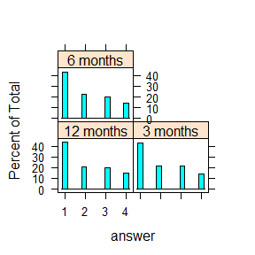

```r
lattice::histogram( ~answer | duration , data=experiment_data)
```

It seems that for each period the around 43% are not willing to download the app. But we can be optimist and classify the 3 and 4 in two different groups to see which conclusion we can get. Because these two groups are probably willing to download the app.

```r
as.data.frame.table(with(experiment_data, table(duration, answer))) %>% filter(answer %in% c(3:4)) %>% group_by(duration) %>% summarise(Freq = sum(Freq)) %>% top_n(1)
```

```
#> # A tibble: 1 x 2
#>   duration  Freq
#>   <fct>    <int>
#> 1 3 months  1277
```

For the **3 months of duration**, the likeliness to download the app seems to be higher. We can conclude that for a smaller duration the number of people who is willing to download the app is higher. The marketing team of the company can reduce the duration to 1, 2 and 3 as different options for the customers. It can be good for customer segmentation too and for the design of the business model.

#We will see how the offer influences the overall likeliness to download

```r
with(experiment_data, table(offer, answer))
```

```
#>                                                       answer
#> offer                                                    1   2   3   4
#>   give you the energy to unlock your fullest potential 990 467 425 329
#>   help you lead a better life                          935 475 447 302
#>   help you sleep without more pills                    884 457 462 291
#>   improve your health for the long-run                 901 475 438 331
#>   improve your sleep sustainably                       915 442 427 311
```

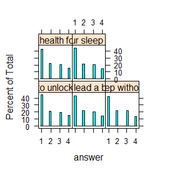

```r
lattice::histogram( ∼ answer | offer , data=experiment_data)
```

For the offer attribute, a large number of customers are not willing to download the app. As in the previous example, we will gather the data for the answer 3 and 4 to evaluate the findings

```r
as.data.frame.table(with(experiment_data, table(offer, answer))) %>% filter(answer %in% c(3:4)) %>% group_by(offer) %>% summarise(Freq = sum(Freq)) %>% top_n(2)
```

```
#> # A tibble: 2 x 2
#>   offer                                                 Freq
#>   <fct>                                                <int>
#> 1 give you the energy to unlock your fullest potential   754
#> 2 improve your health for the long-run                   769
```

The offer **Improve your health for the long-run** can be selected for any further improvement, and can be added to the offer **give you the energy to unlock your fullest potential**. These offers can be merge to rebuild a new offer of the product. The target key words(in order) for the new offer that can be build can be: **Health, Energy, Improve, Give**Or they can merge them for any further analysis.

##### We will see how the outcome influences the overall likeliness to download

```r
with(experiment_data, table(outcome, answer))
```

```
#>                                                answer
#> outcome                                            1    2    3    4
#>   breaking bad habits and creating new routines 1488  786  723  562
#>   changing your sleep mindset                   1544  785  767  510
#>   empowering you to take back your sleep habits 1593  745  709  492
```

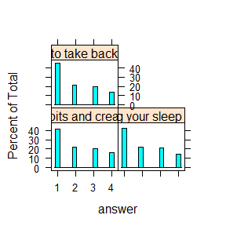

```r
lattice::histogram( ∼ answer | outcome , data=experiment_data)
```

Here also a large number in any case is not willing do download the app. We will proceed to the merging and sorting of the 3 and 4 answers

```r
as.data.frame(with(experiment_data, table(outcome, answer))) %>% filter(answer %in% c(3:4)) %>% group_by(outcome)%>% summarise(Freq = sum(Freq)) %>% top_n(2)
```

```
#> # A tibble: 2 x 2
#>   outcome                                        Freq
#>   <fct>                                         <int>
#> 1 breaking bad habits and creating new routines  1285
#> 2 changing your sleep mindset                    1277
```

The two outcomes can be taken into account for the design of a new one. The key words for the new outcome can be **Bad habits, sleep mindset**

#We will see how price influences the overall likeliness to download

```r
with(experiment_data, table(price, answer))
```

```
#>            answer
#> price          1    2    3    4
#>   $20/month 1309  717  890  634
#>   $30/month 1576  806  725  456
#>   $40/month 1740  793  584  474
```

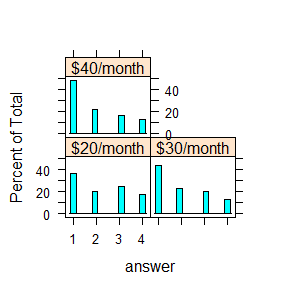

```r
lattice::histogram( ∼ answer | price , data=experiment_data)
```

According to the results the willing to download is rising with the the decrease of the price. We can conclude that $20/month can be one of the price of the product, but it can be split also to 5,10 with different duration to harvest many customers for the benefit of the company.

#We will see how the rtb influences the overall likeliness to download

```r
with(experiment_data, table(rtb, answer))
```

```
#>                                                     answer
#> rtb                                                    1   2   3   4
#>   a program created just for you                     765 384 386 284
#>   cognitive behavioral therapy                       775 407 406 274
#>   daily text messages from a coach                   824 354 344 248
#>   personalized, human coaching                       751 387 362 274
#>   the support of a community of people just like you 754 401 317 255
#>   unique daily games, challenges and exercises       756 383 384 229
```

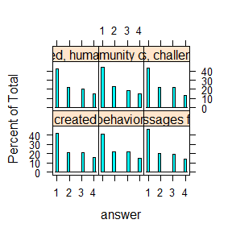

```r
lattice::histogram( ∼ answer | rtb , data=experiment_data)
```

It can be difficult to take a great conclusion form the data, as the largest number is not willing to download the app. We will merge the probably ones together and see how they work

```r
as.data.frame(with(experiment_data, table(rtb, answer))) %>% filter(answer %in% c(3:4)) %>% group_by(rtb) %>% summarise(Freq = sum(Freq)) %>% top_n(2)
```

```
#> # A tibble: 2 x 2
#>   rtb                             Freq
#>   <fct>                          <int>
#> 1 a program created just for you   670
#> 2 cognitive behavioral therapy     680
```

The probably winning rtbs can be these both. Also they have to be merged together to build a new one.

#We will see how the social_proof influences the overall likeliness to download

```r
with(experiment_data, table(social_proof, answer))
```

```
#>                                     answer
#> social_proof                            1    2    3    4
#>   a method that has helped thousands 1183  608  546  365
#>   leading researchers                1095  546  587  379
#>   professional athletes              1199  581  516  381
#>   scientific evidence                1148  581  550  439
```

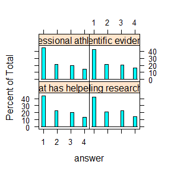

```r
lattice::histogram( ∼ answer | social_proof , data=experiment_data)
```

The same situation here. We will make the same process as previous

```r
as.data.frame(with(experiment_data, table(social_proof, answer))) %>% filter(answer %in% c(3:4)) %>% group_by(social_proof) %>% summarise(Freq = sum(Freq)) %>% top_n(2)
```

```
#> # A tibble: 2 x 2
#>   social_proof         Freq
#>   <fct>               <int>
#> 1 leading researchers   966
#> 2 scientific evidence   989
```

For the social proof these two categories **scientific evidence, leading researchers** are respectvely the top group of customers that can will to download the app. They should have an important attention.

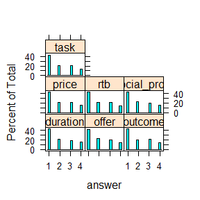

```r
lattice::histogram( ∼ answer | colnames(experiment_data[2:8]) , data=experiment_data)
```

**Conclusion**

In conclusion, from this assessment on the willing to download the app, these following conclusion can be taken into account. For the 3 months of duration, the likeliness to download the app seems to be higher. we recommend that the marketing team of the company can reduce the duration to 1, 2 and 3 as different options for the customers. For the offer attribute, The offer levels **Improve your health for the long-run** can be selected for any further improvement, and can be added to the offer **give you the energy to unlock your fullest potential**. These offers can be merge to rebuild a new offer of the product. The target key words(in order) for the new offer that can be build can be: **Health, Energy, Improve, Give**Or they can merge them for any further analysis. Besides, for the outcome attibute, the two outcomes **breaking bad habits and creating new routines, changing your sleep mindset** can be taken into account for the design of a new one. The key words for the new outcome can be **Bad habits, sleep mindset**. Furthermore, According to the results the willing to download is rising with the the decrease of the price. We can conclude that $20/month can be one of the price of the product, but it can be split also to 5,10 with different duration(1, 2 and 3) to harvest many customers for the benefit of the company. Last but not the least, for The probably winning rtbs can be these both **a program created just for you, cognitive behavioral therapy**. Also they have to be merged together to build a new one. Finally, for the social proof these two categories **scientific evidence, leading researchers** are respectively the top group of customers that can willing to download the app. They should have an important attention.

2. Describe the groups of respondents that we see in the data using the added demographic, psychological and behavioral data. Feel free to experiment with clustering techniques in addition to descriptives.